# Chapter 2: Normal Distribution and Other Stuff

## Normal Distribution: A Simple Explanation

The **normal distribution** (also known as the **Gaussian distribution**) is one of the most commonly used probability distributions in statistics. It has the following characteristics:

1. **Symmetrical Bell Curve**: The distribution has a symmetric shape around its mean, where most of the data points are close to the mean, and fewer are farther away. The further you go from the mean, the less likely the values are.
2. **Mean and Standard Deviation**:
   - The **mean ($\mu$)** represents the “center” or the average of the distribution.
   - The **standard deviation ($\sigma$)** represents how spread out the data is. A larger standard deviation means more variability, and a smaller standard deviation means the data is more tightly packed around the mean.
3. **68-95-99.7 Rule**:
   - About **68%** of the data falls within one standard deviation of the mean.
   - About **95%** falls within two standard deviations.
   - About **99.7%** falls within three standard deviations.

The **normal distribution** is crucial because many real-world phenomena (like heights, test scores, or returns in financial markets) approximate this distribution under certain conditions.

### Visualizing the Normal Distribution

A standard normal distribution (mean = 0, standard deviation = 1) looks like this:

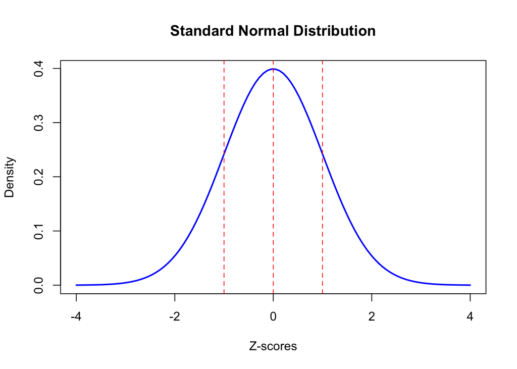

$$\text{This is the PDF of the standard normal: }f(x) =
\frac{1}{\sqrt{2\pi}} e^{-\frac{x^2}{2}}$$

$$\text{This is the PDF of the normal: }f(x) = \frac{1}{\sigma\sqrt{2\pi}}
e^{-\frac{(x-\mu)^2}{2\sigma^2}}$$

Where: $\mu$ is the mean, $\sigma$ is the standard deviation, $e$ is Euler’s number.

A **probability density function (PDF)** describes the likelihood of a **continuous** random variable taking on different values. While the value of the PDF itself is not a probability, the area under the curve between two points represents the probability that the random variable falls within that range.

**The important thing to note is that unlike the discrete random varibales we talked about you can’t evaluate the probabilty that a continuous random variable will take a certain value, but you consider the probability that the continuous random variable will fall within a given range of values.**

In R, the **`pnorm`** and **`qnorm`** functions help you work with the normal distribution:

### **`pnorm(x)`**:

- This function gives the **cumulative probability** up to a point `x` for a normal distribution.
- In other words, it tells you the probability that a random variable from the normal distribution will be **less than or equal** to `x`.
- Think of it as the area under the curve of the normal distribution to the left of `x`.

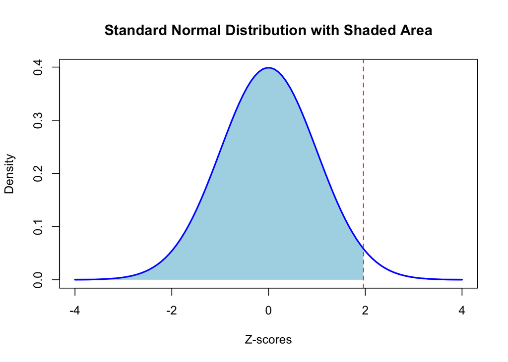

**Example**: # Probability that a value is less than or equal to 1.96 in a standard normal distribution

```r
pnorm(1.96)
```

```
## [1] 0.9750021
```

This returns **0.975**, which means that 97.5% of the values lie below 1.96 in a standard normal distribution.

### **`qnorm(p)`**:

- This is the **inverse** of `pnorm()`. Given a cumulative probability `p`, `qnorm()` returns the value of `x` such that the area to the left of `x` is `p`.
- In simpler terms, it finds the value of `x` that corresponds to a given probability in the normal distribution.

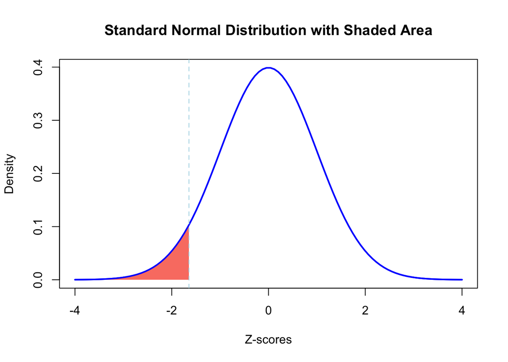

**Example**: # Find the value of x such that 5% of the values lie below it in a standard normal distribution

```r
qnorm(0.05)
```

```
## [1] -1.644854
```

This returns **-1.645**, which means that 5% of the values are less than or equal to -1.645 in a standard normal distribution.

## Example of How to Use `pnorm` and `qnorm` in Practice

### Using `pnorm`:

Suppose you have a dataset with a mean of 100 and a standard deviation of 15 (like IQ scores). You want to know the probability that someone has an IQ less than 120.

```r
mean <- 100
sd <- 15

# Probability that IQ is less than 120
pnorm(120, mean = mean, sd = sd)
```

```
## [1] 0.9087888
```

This will return a value close to **0.908**, meaning about 90.8% of people have an IQ below 120.

### Using `qnorm`:

Now, suppose you want to find the IQ score that corresponds to the top 5% (the 95th percentile).

#### Find the IQ score that corresponds to the 95th percentile

```r
qnorm(0.95, mean = mean, sd = sd)
```

```
## [1] 124.6728
```

This will return approximately **124.67**, meaning that an IQ of about 124.67 is higher than 95% of the population.

## Summary:

- **Normal Distribution**: A bell-shaped, symmetrical distribution described by its mean and standard deviation.
- **`pnorm(x)`**: Returns the probability that a value from the normal distribution is less than or equal to `x`.
- **`qnorm(p)`**: Returns the value `x` such that the probability of a value being less than or equal to `x` is `p`.